# Feature_extraction_pipeline_using_EBImage

Huayu

2019 M08 14

# Image import

Import both original resolution image and image with reduced sise (512 by 512) Immunofluorescent (IF) images are list of 4 channels: Red, Green, Blue and Yellow Green channel is the information channel and the other channels are reference channel: Red (F-actin), Blue (DNA), Yellow (Mitochondria) Resolution of orignal image is recorded

```r
img <- img.Import(index = 1, fileList = img_list)
img_512 <- img.Import_512(index = 1, fileList = img_512_list)

wh <- dim(img$R)[1]

print("structure of img is:")
```

```
## [1] "structure of img is:"
```

```r
str(img)
```

```
## List of 4
##  $ R: num [1:2048, 1:2048] 0.0667 0.0431 0.0627 0.0588 0.0275 ...
##  $ G: num [1:2048, 1:2048] 0 0 0 0 0 0 0 0 0 0 ...
##  $ B: num [1:2048, 1:2048] 0 0 0 0 0 0 0 0 0 0 ...
##  $ Y: num [1:2048, 1:2048] 0.1059 0.0235 0.0392 0.0549 0.0275 ...
```

```r
print("sturcture of img_512 is:")
```

```
## [1] "sturcture of img_512 is:"
```

```r
str(img_512)
```

```
## List of 4
##  $ R: num [1:512, 1:512] 0.0431 0.0196 0 0 0 ...
##  $ G: num [1:512, 1:512] 0.00392 0.00392 0.00784 0 0.00392 ...
##  $ B: num [1:512, 1:512] 0 0 0 0 0 0 0 0 0 0 ...
##  $ Y: num [1:512, 1:512] 0.0824 0.0667 0.149 0.1333 0.0706 ...
```

Preview of the channels

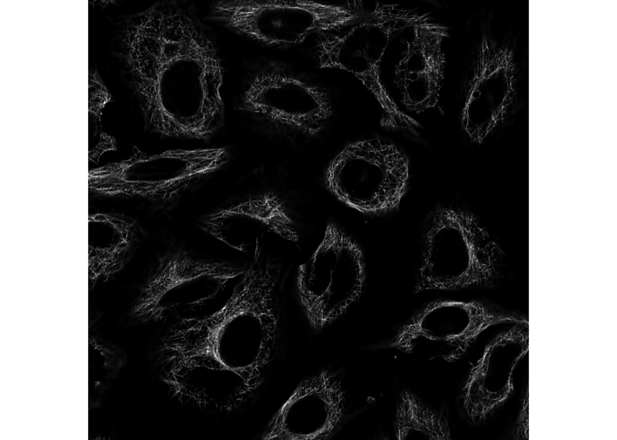

```r
display(img_512$R)
```

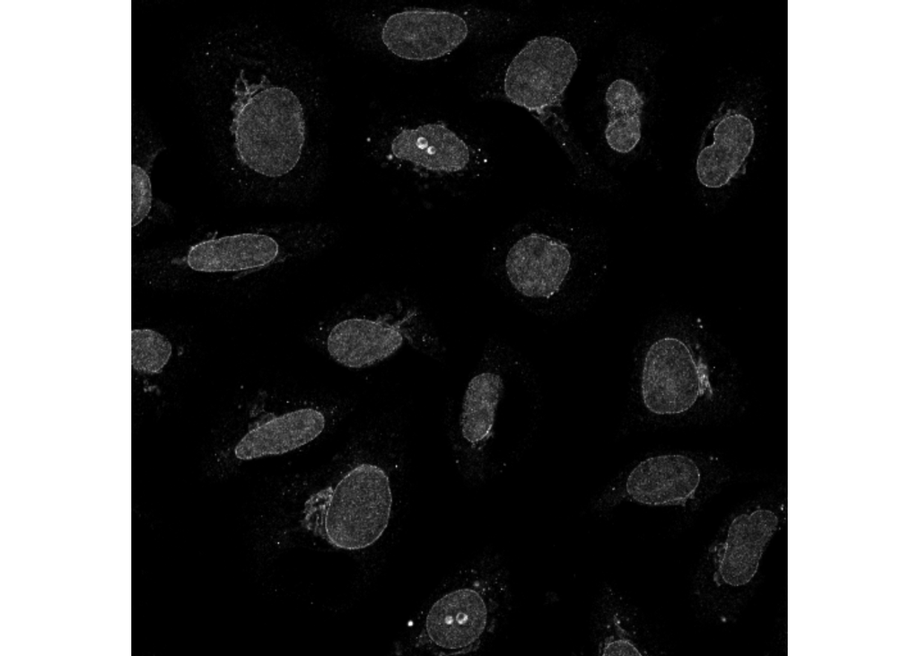

```r
display(img_512$G)
```

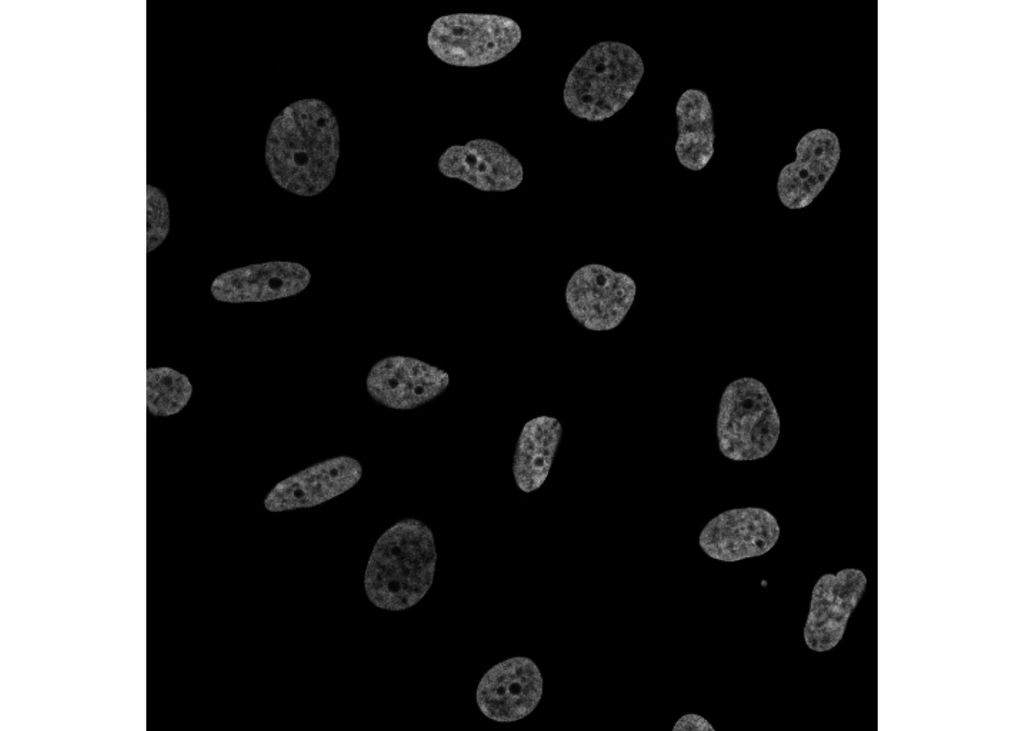

```r
display(img_512$B)
```

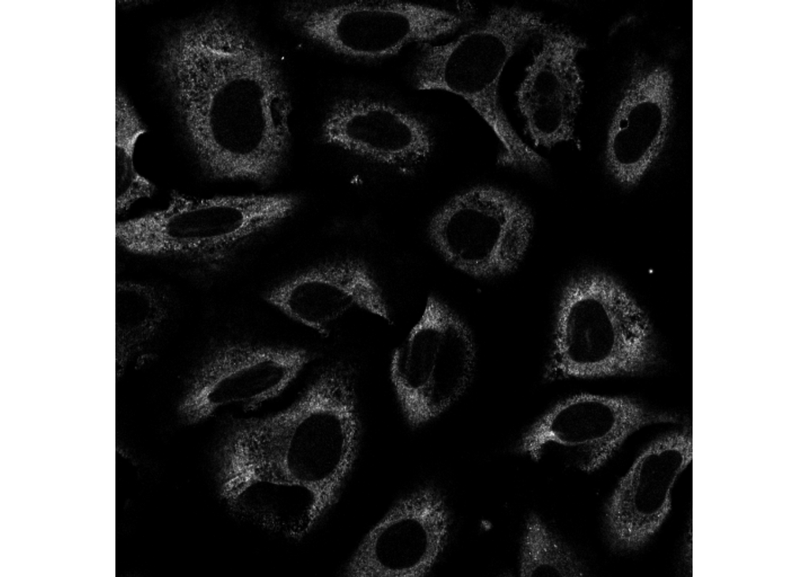

```r
display(img_512$Y)
```

# Object mask creation

This section aims to create the masks for areas and objects in the IF image including: * Nuclei * Cytoplasm * Extracellular area

## Image binarization

Binarize image on cutoff 5/255 higher than background color. Binarized images are used for finilizing the masks. For computation efficiency, low resolution image is used. * DNA reference makes nucleus region * F-actin and mitochondria conbined for cytoplasm region

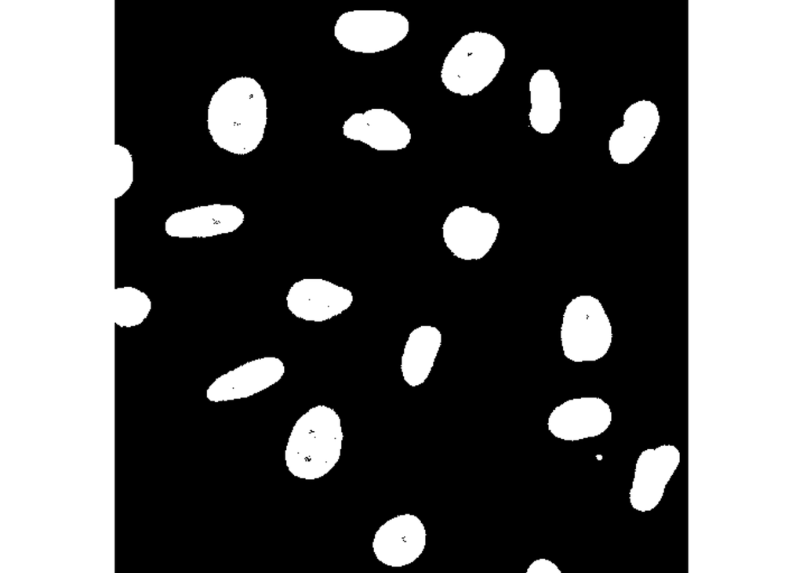

```r
img_cutoffs <- sapply(img_512, binChannel)

img_bin_512 <- list(
      "R" = img_512$R > img_cutoffs["R"],
      "G" = img_512$G > img_cutoffs["G"],
      "B" = img_512$B > img_cutoffs["B"],
      "Y" = img_512$Y > img_cutoffs["Y"]
    )

display(img_bin_512$B)
```

## Fillhull, watershed and remove noices

Fill the holes in large areas

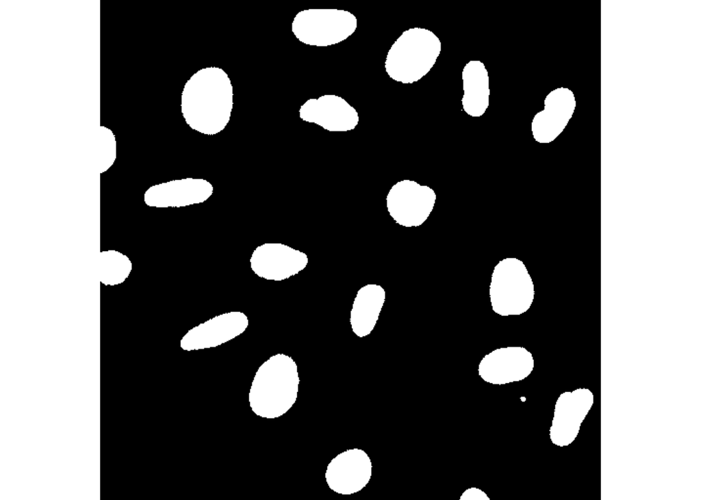

```r
img_masks_512 <- list(
      "B" = fillHull(img_bin_512$B),
      "RY" = img_bin_512$R | img_bin_512$Y
    )

display(img_masks_512$B)
```

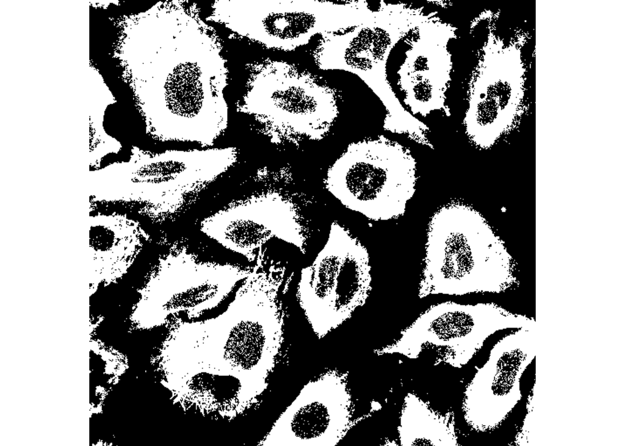

```r
display(img_masks_512$RY)
```

Watershedding to define objects Remove extra small objects, which are noise dots Watershedding returns number matrix same size as the image. Indexes are given to objects, and number 0 is give to background. Objects on the edge of the image are removed, becasue they are outlayers for many calculations.

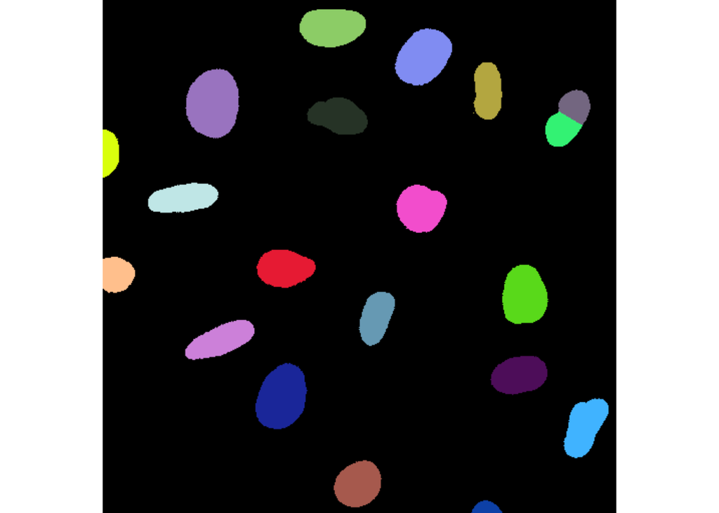

```r
img_masks_512$B <- watershed(x = distmap(img_masks_512$B), tolerance = 1, ext = 3)
img_table_512 <- list(
      "B" = table(img_masks_512$B)
    )
img_masks_512$B <- rmObjects(x = img_masks_512$B, index = names(img_table_512$B)[img_table_512$B < 100])
img_table_512$B <- table(img_masks_512$B)

img_table_512$Bminus <- table(img_masks_512$B[2:511, 2:511])
img_masks_512$Bminus <- rmObjects(x = img_masks_512$B, index = names(img_table_512$B)[img_table_512$B > img_table_512$Bminus])

display(colorLabels(img_masks_512$B))
```

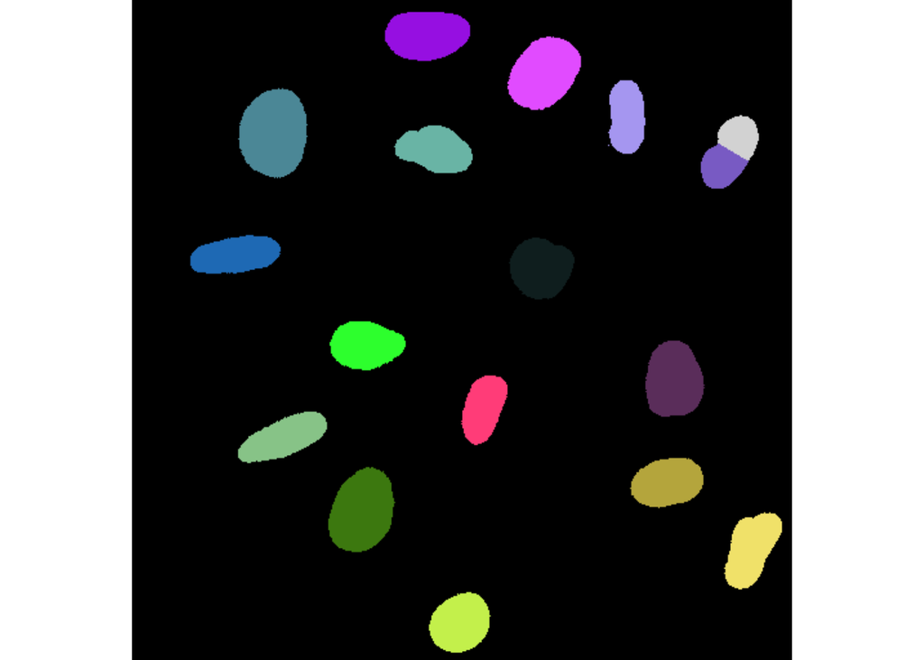

```r
display(colorLabels(img_masks_512$Bminus))
```

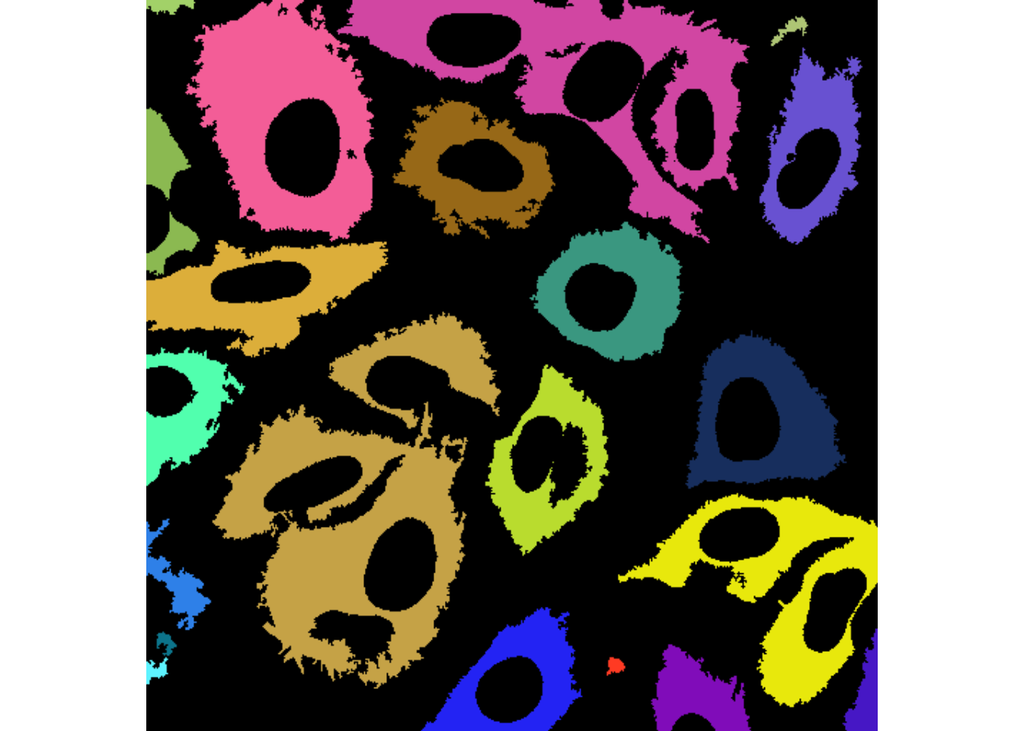

```r
img_masks_512$RYinv <- bwlabel(1 - img_masks_512$RY)
img_table_512$RYinv <- table(img_masks_512$RYinv)
img_masks_512$RYinv <- rmObjects(x = img_masks_512$RYinv, index = names(img_table_512$RYinv)[img_table_512$RYinv > 20])
img_masks_512$RY[img_masks_512$RYinv > 0] <- 1
img_masks_512$RYinv <- NULL

img_masks_512$RY <- bwlabel(img_masks_512$RY)
img_table_512$RY <- table(img_masks_512$RY)
img_masks_512$RY <- rmObjects(x = img_masks_512$RY, index = names(img_table_512$RY)[img_table_512$RY < 100])
img_masks_512$RY[img_masks_512$B > 0] <- 0

display(colorLabels(img_masks_512$RY))
```

Create mask for rim of nuclei, great mask for identifying nucleomembrane

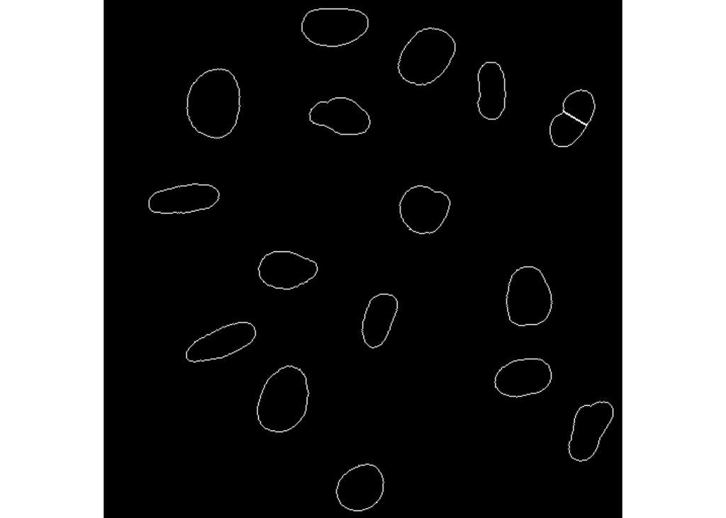

```r
img_masks_512$rimB <- rimOfNuclei(nucMask = img_masks_512$Bminus)
display(x = img_masks_512$rimB)
```

## Upscale of the masks to full resolution

```r
img_masks <- lapply(img_masks_512, function(x, fact) as.matrix(disaggregate(x = raster(x), fact = fact)), fact = wh/512)
```

# Masks for signals in green channel

## Segmentation of green channel signals

Disect the green signal according to the masks (subcellular areas)

```r
img_Green <- list(
      "Nucleus" = img$G,
      "Cytosol" = img$G,
      "Rest" = img$G
    )

    img_Green$Nucleus[img_masks$B == 0] <- 0
    img_Green$Cytosol[img_masks$RY == 0] <- 0
    img_Green$Rest[img_masks$B > 0| img_masks$RY > 0 ] <- 0

    display(img_Green$Nucleus)
```

[figure not shown]

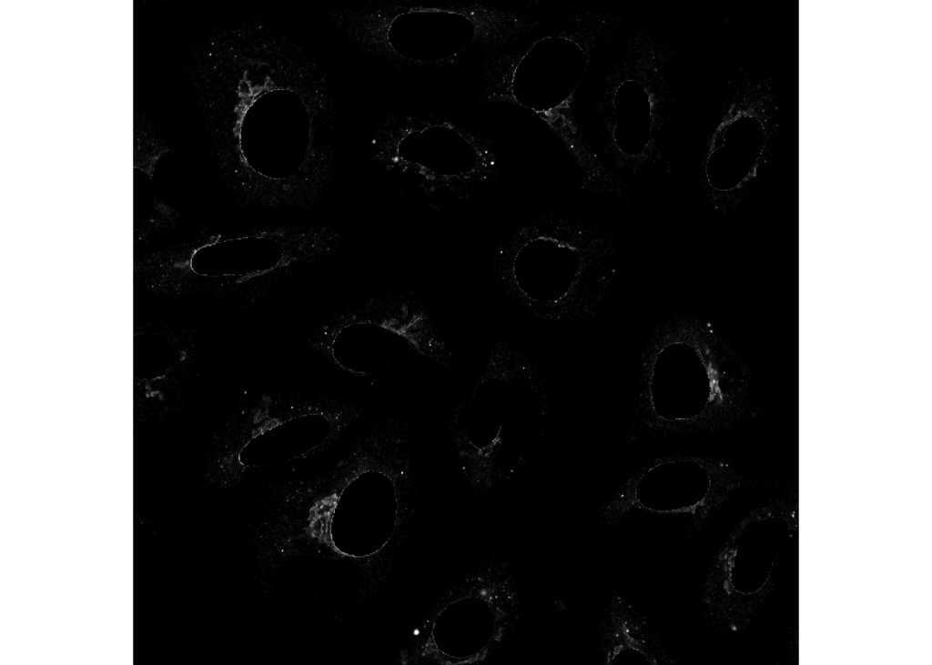

```r
    display(img_Green$Cytosol)
```

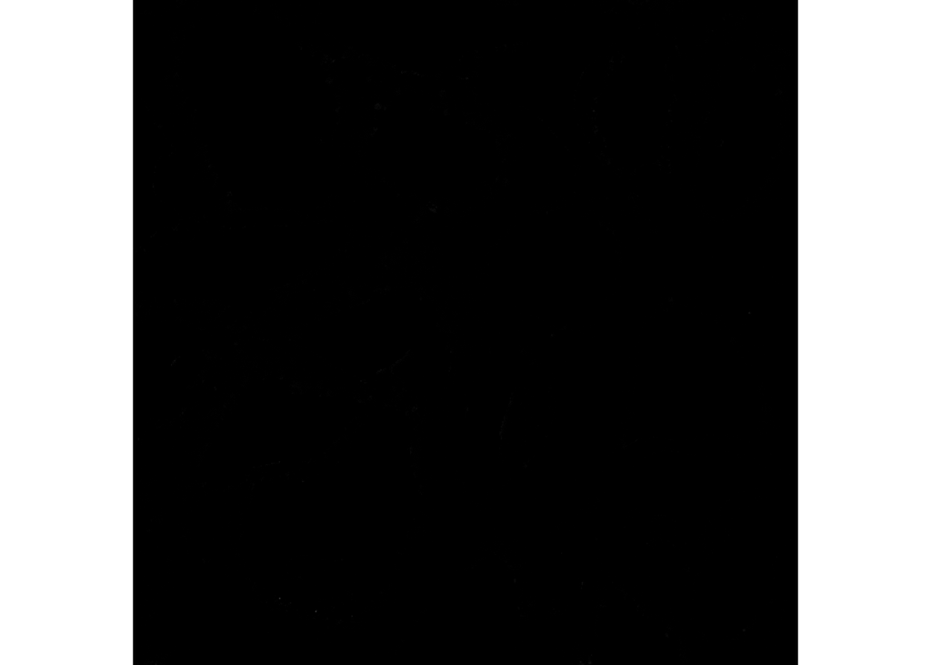

```r
    display(img_Green$Rest)
```

## Object masks for Green signals

Emprical way to deside cutoffs for green signal Method 1: Otsu method which is more loose Method 2: Right most fluctuation of 2nd derivative/Right most non-zero 2nd derivative, which is more stringent For Nuclues and Cytosol use both methods For Rest use Otsu only Libraries with too many labels is a huge computation burden, sampling will be done

The otsu cutoff

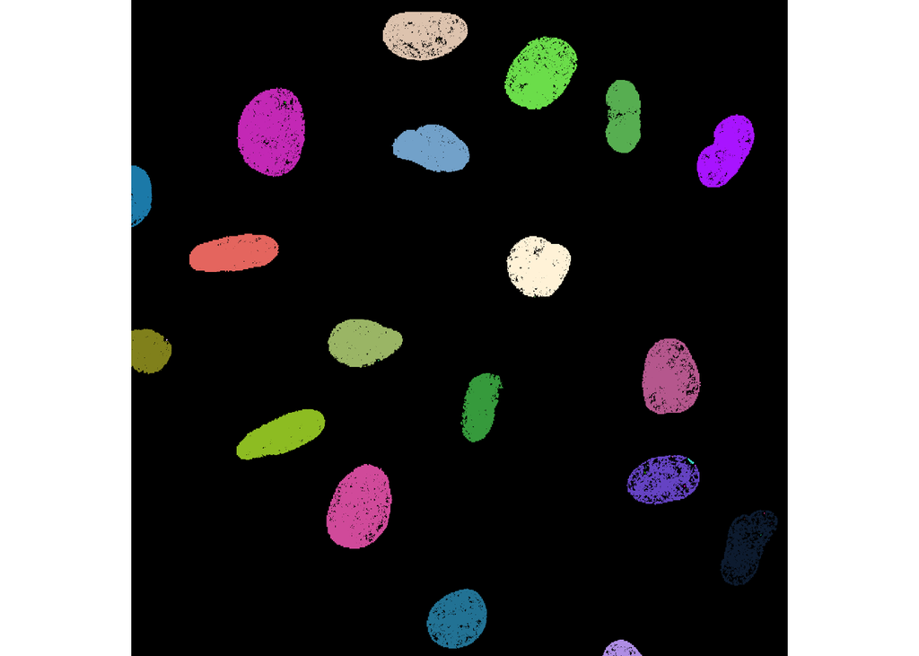

```r
img_cutoffs <- c(img_cutoffs,
                     G.Otsu = sapply(img_Green, otsu),
                     G.Huayu = sapply(img_Green[1:2], huayu.cutoff),
                     G.Otsu = otsu(img_512$G),
                     G.Huayu = huayu.cutoff(img_512$G),
                     "R.Otsu" = otsu(img_512$R),
                     "B.Otsu" = otsu(img_512$B),
                     "Y.Otsu" = otsu(img_512$Y)
    )


img_masks_G.Otsu <- list(
      "Nucleus" = bwlabel(x = img_Green$Nucleus > img_cutoffs["G.Otsu.Nucleus"]),
      "Cytosol" = bwlabel(x = img_Green$Cytosol > img_cutoffs["G.Otsu.Cytosol"]),
      "Rest" = bwlabel(x = img_Green$Rest > img_cutoffs["G.Otsu.Rest"])

    )

img_table_G.Otsu <- lapply(X = img_masks_G.Otsu, FUN = table)

img_masks_G.Otsu$Nucleus <- rmObjects(
  x = img_masks_G.Otsu$Nucleus,
  index = names(img_table_G.Otsu$Nucleus)[img_table_G.Otsu$Nucleus < 10])

if (sum(img_table_G.Otsu$Nucleus >= 10) > 200)
  img_masks_G.Otsu$Nucleus <- rmObjects(
    x = img_masks_G.Otsu$Nucleus,
    index = names(img_table_G.Otsu$Nucleus)[sample(1:sum(img_table_G.Otsu$Nucleus >= 10), sum(img_table_G.Otsu$Nucleus >= 10) - 200)])


img_masks_G.Otsu$Cytosol <- rmObjects(
  x = img_masks_G.Otsu$Cytosol,
  index = names(img_table_G.Otsu$Cytosol)[img_table_G.Otsu$Cytosol < 10])
if (sum(img_table_G.Otsu$Cytosol >=10) > 200)
      img_masks_G.Otsu$Cytosol <- rmObjects(
        x = img_masks_G.Otsu$Cytosol,
        index = names(img_table_G.Otsu$Cytosol)[sample(1:sum(img_table_G.Otsu$Cytosol >= 10), sum(img_table_G.Otsu$Cytosol >= 10) - 200)])

img_masks_G.Otsu$Rest <- rmObjects(
      x = img_masks_G.Otsu$Rest,
      index = names(img_table_G.Otsu$Rest)[img_table_G.Otsu$Rest < 10])
if (sum(img_table_G.Otsu$Rest >=10) > 200)
      img_masks_G.Otsu$Rest <- rmObjects(
        x = img_masks_G.Otsu$Rest,
        index = names(img_table_G.Otsu$Rest)[sample(1:sum(img_table_G.Otsu$Rest >= 10), sum(img_table_G.Otsu$Rest >= 10) - 200)])

display(colorLabels(img_masks_G.Otsu$Nucleus))
```

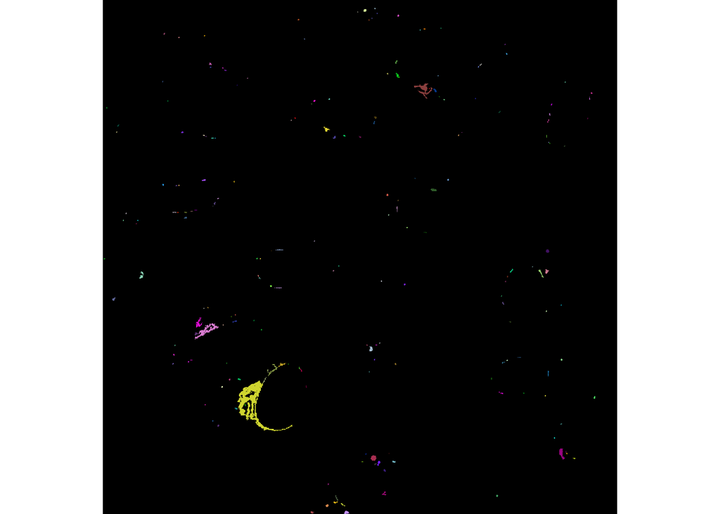

```r
display(colorLabels(img_masks_G.Otsu$Cytosol))
```

My customized cutoff This more strigent cutoff captures objects with very strong signals, such as substructures in nuclei.

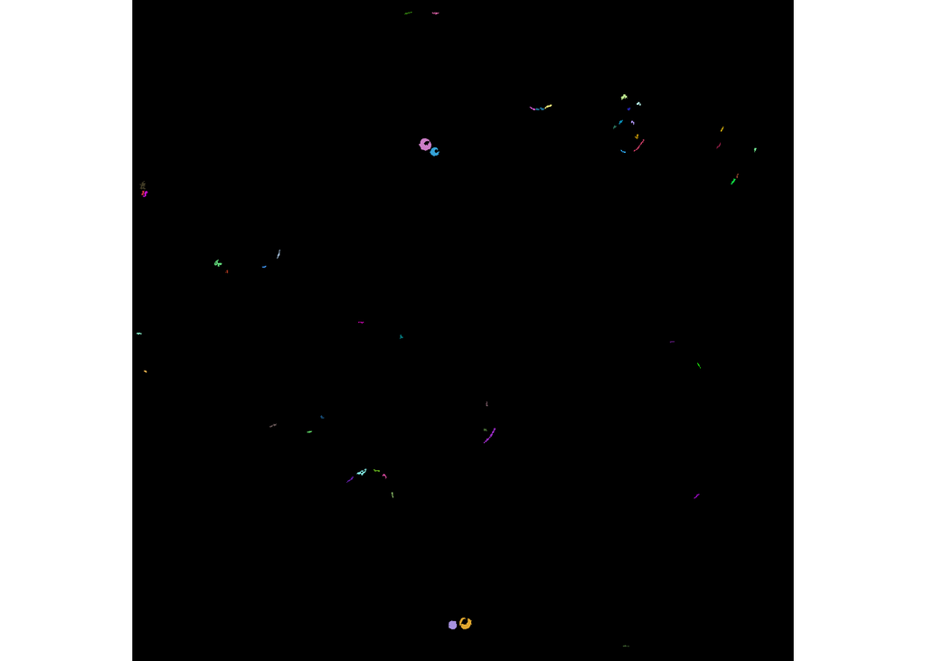

```r
img_masks_G.Huayu <- list(
      "Nucleus" = bwlabel(x = img_Green$Nucleus > img_cutoffs["G.Huayu.Nucleus"]),
      "Cytosol" = bwlabel(x = img_Green$Cytosol > img_cutoffs["G.Huayu.Cytosol"])
    )

img_table_G.Huayu <- lapply(X = img_masks_G.Huayu, FUN = table)


if (sum(img_table_G.Huayu$Nucleus >= 10) > 100)
    img_masks_G.Huayu$Nucleus <- rmObjects(
      x = img_masks_G.Huayu$Nucleus,
      index = names(img_table_G.Huayu$Nucleus)[order(img_table_G.Huayu$Nucleus, decreasing = T)[51:length(img_table_G.Huayu$Nucleus)]])


if (sum(img_table_G.Huayu$Cytosol >=10) > 100)
    img_masks_G.Huayu$Cytosol <- rmObjects(
      x = img_masks_G.Huayu$Cytosol,
      index = names(img_table_G.Huayu$Cytosol)[order(img_table_G.Huayu$Cytosol, decreasing = T)[51:length(img_table_G.Huayu$Cytosol)]])


display(colorLabels(img_masks_G.Huayu$Nucleus))
```

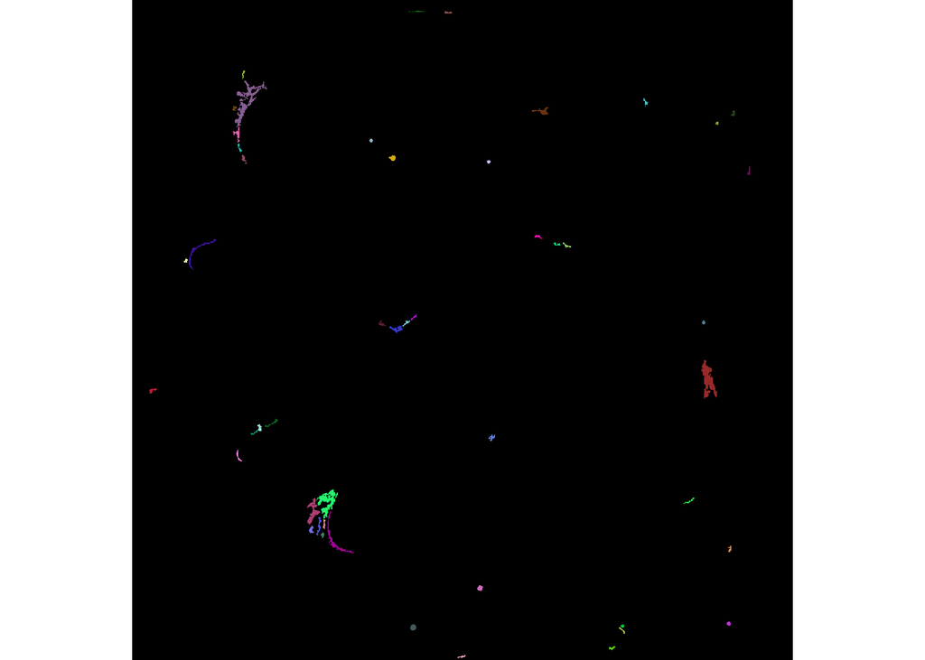

```r
display(colorLabels(img_masks_G.Huayu$Cytosol))
```

# Compute object features

Features are computed using * colocolization of green signal to reference channels * Object properties using masks

```r
manualFeatures <- c(
      "GcolocB" = coloc(bin1 = img$G > img_cutoffs["G.Otsu"], bin2 = img$B > img_cutoffs["B.Otsu"]),
      "GcolocR" = coloc(bin1 = img$G > img_cutoffs["G.Otsu"], bin2 = img$R > img_cutoffs["R.Otsu"]),
      "GcolocY" = coloc(bin1 = img$G > img_cutoffs["G.Otsu"], bin2 = img$Y > img_cutoffs["Y.Otsu"]),
      "GcolocRimB" = coloc(bin1 = img$G > img_cutoffs["G.Otsu"], bin2 = img_masks$rimB),
      img_cutoffs
    )



featureList <- list(
      "manualFeatures" = manualFeatures,
      "M.Blue_Its.Blue" = computeFeatures(x = img_masks$B, ref = img$B), ##Mask: Blue, Ref: Blue, Information of nucleus properties
      "M.Blue_Its.Green" = computeFeatures(x = img_masks$B, ref = img$G), ##Mask: Blue, Ref: Green, Gain: Average signal properties per nucleus
      "M.G.Nuc.Otsu_Its.Green" = computeFeatures(x = img_masks_G.Otsu$Nucleus, ref = img$G), ##Mask: HDR Green in Nucleus, Ref: Green, Gain: Green signal properties in Nucleus
      "M.G.Nuc.Huayu_Its.Green" = computeFeatures(x = img_masks_G.Huayu$Nucleus, ref = img$G), ##See above
      "M.G.Cyt.Otsu_Its.Green" = computeFeatures(x = img_masks_G.Otsu$Cytosol, ref = img$G),##Mask: HDR Green in Cytosol, Ref: Green, Gain: Green signal properties in Cytosol
      "M.G.Cyt.Huayu_Its.Green" = computeFeatures(x = img_masks_G.Huayu$Cytosol, ref = img$G), ##See above
      "M.G.Rest.Otsu_Its.Green" = computeFeatures(x = img_masks_G.Otsu$Rest, ref = img$G),##Mask: Green in Rest, Ref: Green, Gain: Green signal properties in Rest
      "M.G.Cyt.Otsu_Its.Red" = computeFeatures(x = img_masks_G.Otsu$Cytosol, ref = img$R),##Mask: HDR Green in Cytosol, Ref: Red, Gain: Relation of green signal and red signal
      "M.G.Cyt.Huayu_Its.Red" = computeFeatures(x = img_masks_G.Huayu$Cytosol, ref = img$R),##See above
      "M.G.Cyt.Otsu_Its.Yellow" = computeFeatures(x = img_masks_G.Otsu$Cytosol, ref = img$Y),##Mask: HDR Green in Cytosol, Ref: Yellow, Gain: Relation of green signal and yellow signal
      "M.G.Cyt.Huayu_Its.Yellow" = computeFeatures(x = img_masks_G.Huayu$Cytosol, ref = img$Y)##See above
    )
```

The featureList objects contain all colocalization, shape and texture features.

```r
str(featureList)
```

```
## List of 12
##  $ manualFeatures          : Named num [1:18] 0.807 0.1283 0.1304 0.0911 0.0235 ...
##   ..- attr(*, "names")= chr [1:18] "GcolocB" "GcolocR" "GcolocY" "GcolocRimB" ...
##  $ M.Blue_Its.Blue         : num [1:20, 1:89] 440 713 1278 1681 1269 ...
##   ..- attr(*, "dimnames")=List of 2
##   .. ..$ : chr [1:20] "1" "2" "3" "4" ...
##   .. ..$ : chr [1:89] "x.0.m.cx" "x.0.m.cy" "x.0.m.majoraxis" "x.0.m.eccentricity" ...
##  $ M.Blue_Its.Green        : num [1:20, 1:89] 440 713 1278 1681 1269 ...
##   ..- attr(*, "dimnames")=List of 2
##   .. ..$ : chr [1:20] "1" "2" "3" "4" ...
##   .. ..$ : chr [1:89] "x.0.m.cx" "x.0.m.cy" "x.0.m.majoraxis" "x.0.m.eccentricity" ...
##  $ M.G.Nuc.Otsu_Its.Green  : num [1:38, 1:89] 912 1277 958 1535 438 ...
##   ..- attr(*, "dimnames")=List of 2
##   .. ..$ : chr [1:38] "1" "2" "3" "4" ...
##   .. ..$ : chr [1:89] "x.0.m.cx" "x.0.m.cy" "x.0.m.majoraxis" "x.0.m.eccentricity" ...
##  $ M.G.Nuc.Huayu_Its.Green : num [1:49, 1:89] 854 939 1522 1568 1288 ...
##   ..- attr(*, "dimnames")=List of 2
##   .. ..$ : chr [1:49] "1" "2" "3" "4" ...
##   .. ..$ : chr [1:89] "x.0.m.cx" "x.0.m.cy" "x.0.m.majoraxis" "x.0.m.eccentricity" ...
##  $ M.G.Cyt.Otsu_Its.Green  : num [1:200, 1:89] 1083 1043 1014 1092 1176 ...
##   ..- attr(*, "dimnames")=List of 2
##   .. ..$ : chr [1:200] "1" "2" "3" "4" ...
##   .. ..$ : chr [1:89] "x.0.m.cx" "x.0.m.cy" "x.0.m.majoraxis" "x.0.m.eccentricity" ...
##  $ M.G.Cyt.Huayu_Its.Green : num [1:49, 1:89] 884 978 344 355 1591 ...
##   ..- attr(*, "dimnames")=List of 2
##   .. ..$ : chr [1:49] "1" "2" "3" "4" ...
##   .. ..$ : chr [1:89] "x.0.m.cx" "x.0.m.cy" "x.0.m.majoraxis" "x.0.m.eccentricity" ...
##  $ M.G.Rest.Otsu_Its.Green : num [1:155, 1:89] 1147 518 708 595 696 ...
##   ..- attr(*, "dimnames")=List of 2
##   .. ..$ : chr [1:155] "1" "2" "3" "4" ...
##   .. ..$ : chr [1:89] "x.0.m.cx" "x.0.m.cy" "x.0.m.majoraxis" "x.0.m.eccentricity" ...
##  $ M.G.Cyt.Otsu_Its.Red    : num [1:200, 1:89] 1083 1043 1014 1092 1176 ...
##   ..- attr(*, "dimnames")=List of 2
##   .. ..$ : chr [1:200] "1" "2" "3" "4" ...
##   .. ..$ : chr [1:89] "x.0.m.cx" "x.0.m.cy" "x.0.m.majoraxis" "x.0.m.eccentricity" ...
##  $ M.G.Cyt.Huayu_Its.Red   : num [1:49, 1:89] 884 978 344 355 1591 ...
##   ..- attr(*, "dimnames")=List of 2
##   .. ..$ : chr [1:49] "1" "2" "3" "4" ...
##   .. ..$ : chr [1:89] "x.0.m.cx" "x.0.m.cy" "x.0.m.majoraxis" "x.0.m.eccentricity" ...
##  $ M.G.Cyt.Otsu_Its.Yellow : num [1:200, 1:89] 1083 1043 1014 1092 1176 ...
##   ..- attr(*, "dimnames")=List of 2
##   .. ..$ : chr [1:200] "1" "2" "3" "4" ...
##   .. ..$ : chr [1:89] "x.0.m.cx" "x.0.m.cy" "x.0.m.majoraxis" "x.0.m.eccentricity" ...
##  $ M.G.Cyt.Huayu_Its.Yellow: num [1:49, 1:89] 884 978 344 355 1591 ...
##   ..- attr(*, "dimnames")=List of 2
##   .. ..$ : chr [1:49] "1" "2" "3" "4" ...
##   .. ..$ : chr [1:89] "x.0.m.cx" "x.0.m.cy" "x.0.m.majoraxis" "x.0.m.eccentricity" ...
```